# Final Project 2: R Markdown

Xaviera Villarino

# Introduction

The data set used in this project is one I simulated to be similar (but not exactly like) the 2022 cycle of the American Men’s Internet Survey (AMIS). This survey is a web-based cross-sectional survey that is distributed to men who have sex with men (MSM) who are recruited through online advertisements on websites and social media platforms such as Grindr and Instagram.

The goal of this analysis is to obtain basic descriptive stats and create figures that allow us to better examine the distribution of participants in our study among the different testing frequencies/categories of the outcome and for all the predictors of interest. The 10 predictors/variables of interest with respect to HIV/STI testing frequency are: age, education, food security, income, insurance, pre-exposure prophylaxis (PrEP) use, race, Census region, rural/urban classification, and stigma.

# Table 1: Demographic Information of Study Population

|  | annual (N=48) | greater than annual (N=265) | less than annual (N=187) | Overall (N=500) |
| --- | --- | --- | --- | --- |
| Age (y) |  |  |  |  |
| 15-24 | 5 (10.4%) | 16 (6.0%) | 23 (12.3%) | 44 (8.8%) |
| 25-29 | 6 (12.5%) | 37 (14.0%) | 17 (9.1%) | 60 (12.0%) |
| 30-39 | 10 (20.8%) | 51 (19.2%) | 33 (17.6%) | 94 (18.8%) |
| 40+ | 27 (56.3%) | 161 (60.8%) | 114 (61.0%) | 302 (60.4%) |
| Race |  |  |  |  |
| Hispanic | 3 (6.3%) | 30 (11.3%) | 24 (12.8%) | 57 (11.4%) |
| non-Hispanic black | 5 (10.4%) | 23 (8.7%) | 10 (5.3%) | 38 (7.6%) |
| non-Hispanic white | 34 (70.8%) | 184 (69.4%) | 129 (69.0%) | 347 (69.4%) |
| Other,multiple,unknown | 6 (12.5%) | 28 (10.6%) | 24 (12.8%) | 58 (11.6%) |
| Household Income (/year) |  |  |  |  |
| $0-$19,999 | 5 (10.4%) | 19 (7.2%) | 20 (10.7%) | 44 (8.8%) |
| $20,000-$39,999 | 7 (14.6%) | 29 (10.9%) | 21 (11.2%) | 57 (11.4%) |
| $40,000-$74,999 | 12 (25.0%) | 56 (21.1%) | 29 (15.5%) | 97 (19.4%) |
| $75,000+ | 24 (50.0%) | 161 (60.8%) | 117 (62.6%) | 302 (60.4%) |
| Highest Education Obtained |  |  |  |  |
| College degree or postgraduate education | 27 (56.3%) | 177 (66.8%) | 120 (64.2%) | 324 (64.8%) |
| HS diploma or equivalent | 7 (14.6%) | 17 (6.4%) | 22 (11.8%) | 46 (9.2%) |
| Some college or technical degree | 14 (29.2%) | 66 (24.9%) | 41 (21.9%) | 121 (24.2%) |
| less than HS diploma | 0 (0%) | 5 (1.9%) | 4 (2.1%) | 9 (1.8%) |
| PrEP use in past 12 months |  |  |  |  |
| No | 19 (39.6%) | 133 (50.2%) | 95 (50.8%) | 247 (49.4%) |
| Yes | 29 (60.4%) | 132 (49.8%) | 92 (49.2%) | 253 (50.6%) |
| Ever experienced stigma |  |  |  |  |
| No | 32 (66.7%) | 135 (50.9%) | 106 (56.7%) | 273 (54.6%) |
| Yes | 16 (33.3%) | 130 (49.1%) | 81 (43.3%) | 227 (45.4%) |
| Rural/Urban Classification (NCHS 2013) |  |  |  |  |
| Large central metro | 21 (43.8%) | 104 (39.2%) | 66 (35.3%) | 191 (38.2%) |
| Large fringe metro | 5 (10.4%) | 51 (19.2%) | 34 (18.2%) | 90 (18.0%) |
| Medium metro | 13 (27.1%) | 44 (16.6%) | 46 (24.6%) | 103 (20.6%) |
| Micropolitan | 2 (4.2%) | 26 (9.8%) | 8 (4.3%) | 36 (7.2%) |
| Non core | 2 (4.2%) | 19 (7.2%) | 15 (8.0%) | 36 (7.2%) |
| Small metro | 5 (10.4%) | 21 (7.9%) | 18 (9.6%) | 44 (8.8%) |
| Experienced Food Insecurity |  |  |  |  |
| No | 37 (77.1%) | 219 (82.6%) | 160 (85.6%) | 416 (83.2%) |
| Yes | 11 (22.9%) | 46 (17.4%) | 27 (14.4%) | 84 (16.8%) |
| Region |  |  |  |  |
| Midwest | 10 (20.8%) | 50 (18.9%) | 35 (18.7%) | 95 (19.0%) |
| Northeast | 10 (20.8%) | 60 (22.6%) | 39 (20.9%) | 109 (21.8%) |
| South | 17 (35.4%) | 106 (40.0%) | 79 (42.2%) | 202 (40.4%) |
| West | 11 (22.9%) | 49 (18.5%) | 34 (18.2%) | 94 (18.8%) |
| Insurance Status |  |  |  |  |
| None | 4 (8.3%) | 23 (8.7%) | 11 (5.9%) | 38 (7.6%) |
| Other/Multiple | 2 (4.2%) | 8 (3.0%) | 4 (2.1%) | 14 (2.8%) |
| Private Only | 31 (64.6%) | 173 (65.3%) | 136 (72.7%) | 340 (68.0%) |
| Public Only | 11 (22.9%) | 61 (23.0%) | 36 (19.3%) | 108 (21.6%) |

# Figure: Bar Chart of Participant Distribution by HIV/STI Testing Frequency

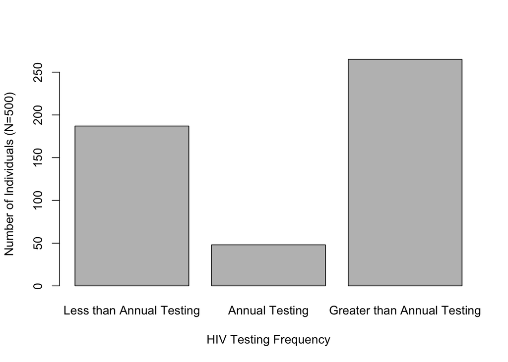

The figure above is a simple bar chart depicting the distribution of study participants by HIV testing frequency. The testing frequency variable was created based on a survey question that assessed how many times the participants had gotten tested for HIV in the past two years. Those who reported testing 1 or less times in the past two years were classified as “less than annual testing”,those who reported testing 2 times were classified as “annual testing” and those who reported testing 3 or more times were classified as “greater than annual testing”. The majority of participants tested greater than annually (n=265). Less than annual testing was the second highest in frequency (n=187). Lastly, with the lowest frequency is annual testing (n=48).